# Practice: Association Rule

# 大樂透獎號關聯式分析

```r
library(arules)
library(arulesViz)
```

資料為透過專用 python 爬蟲套件 https://github.com/stu01509/TaiwanLotteryCrawler 爬取 2023 年 01 月 01 日起至 2025 年 03 月 07 日，共 267 期的大樂透開獎獎號，爬下資料儲存於 https://github.com/PingYangChen/BDA_Course_R_Code/blob/main/sample_data/lotto_2023-202503037.csv。

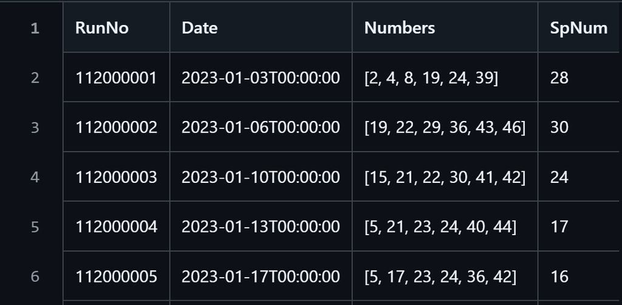

## 讀取資料並整理成關聯式分析所需格式

```r
# Read data from the github link
url <- 'https://raw.githubusercontent.com/PingYangChen/BDA_Course_R_Code/refs/heads/main/sample_data/lotto_2023-202503037.csv'
df <- read.csv(url)
# Display a few rows of the dataframe
head(df, 6)
```

```
##       RunNo                Date                  Numbers SpNum
## 1 112000001 2023-01-03T00:00:00    [2, 4, 8, 19, 24, 39]    28
## 2 112000002 2023-01-06T00:00:00 [19, 22, 29, 36, 43, 46]    30
## 3 112000003 2023-01-10T00:00:00 [15, 21, 22, 30, 41, 42]    24
## 4 112000004 2023-01-13T00:00:00  [5, 21, 23, 24, 40, 44]    17
## 5 112000005 2023-01-17T00:00:00  [5, 17, 23, 24, 36, 42]    16
## 6 112000006 2023-01-20T00:00:00 [16, 25, 27, 31, 34, 42]     6
```

從 **arules** 的範例對照，在此的購物車資料定義應為

- 期別 RunNo ：transaction ID (tid)
- 獎號 Numbers：item

且 **arules** 需要的 `dataframe` 格式如下

```r
data.frame(tid = rep("112000001", 6), item = c(2, 4, 8, 19, 24, 39))
```

```
##         tid item
## 1 112000001    2
## 2 112000001    4
## 3 112000001    8
## 4 112000001   19
## 5 112000001   24
## 6 112000001   39
```

每期為一個單位的購物車（transaction ID），每期開出六個號碼（items），則每期資料應在 `dataframe` 中佔 6 列。

觀察原始資料的第一筆獎號 [2, 4, 8, 19, 24, 39]，此原為字串，前後有中括號，數字已逗號分隔。 需要從字串移除中括號，並分離出六個整數。

- 移除中括號：使用字串處理函數 `strspilt`，依次將左中括號 `\\[`、右中括號 `\\]` 分離。

```r
tmp0 <- strsplit(df$Numbers[1], "\\[")
print(tmp0)
```

```
## [[1]]
## [1] ""                     "2, 4, 8, 19, 24, 39]"
```

```r
tmp1 <- strsplit(tmp0[[1]][2], "\\]")
print(tmp1)
```

```
## [[1]]
## [1] "2, 4, 8, 19, 24, 39"
```

- 拆解逗號分離：使用字串處理函數 `strspilt`，以逗號 `,` 作為切分點切割字串。

```r
tmp2 <- strsplit(tmp1[[1]][1], ",")
print(tmp2)
```

```
## [[1]]
## [1] "2"   " 4"  " 8"  " 19" " 24" " 39"
```

- 整數化：使用函數 `as.integer`，以逗號 `,` 將六個整數字串串列轉為整數串列。

```r
as.integer(tmp2[[1]])
```

```
## [1]  2  4  8 19 24 39
```

將以上步驟整合成為可調用的函數

```r
SplitNumbers <- function(num_list) {
  tmp0 <- strsplit(num_list, "\\[")
  tmp1 <- strsplit(tmp0[[1]][2], "\\]")
  tmp2 <- strsplit(tmp1[[1]][1], ",")
  out <- as.integer(tmp2[[1]])
  return(out)
}
```

建立購物車資料，滿足 **arules** 需要的 `dataframe`

```r
item_vec <- tid_vec <- c()
for (i in 1:nrow(df)) {
  itmp <- SplitNumbers(df$Numbers[i])
  item_vec <- c(item_vec, itmp)
  tid_vec <- c(tid_vec, rep(df$RunNo[i], length(itmp)))
}
df_trans <- data.frame(tid = tid_vec, item = item_vec)
```

最後將此 `dataframe` 改為 `"transactions"` 格式，即完成資料前處理。

```r
df_arules <- as(split(df_trans$item, df_trans$tid), "transactions")
inspect(head(df_arules, n = 6))
```

```
##     items                    transactionID
## [1] {2, 4, 8, 19, 24, 39}    112000001
## [2] {19, 22, 29, 36, 43, 46} 112000002
## [3] {15, 21, 22, 30, 41, 42} 112000003
## [4] {5, 21, 23, 24, 40, 44}  112000004
## [5] {5, 17, 23, 24, 36, 42}  112000005
## [6] {16, 25, 27, 31, 34, 42} 112000006
```

## 建立關聯式規則

```r
rules <- apriori(df_arules,
                 parameter = list(
                   support = 0.01,   # minimal support of an item set
                   confidence = 0.5, # minimal confidence of rules/association hyperedges
                   minlen = 1 # minimal number of items per item set
                 ))
```

```
## Apriori
##
## Parameter specification:
##  confidence minval smax arem  aval originalSupport maxtime support minlen
##         0.5    0.1    1 none FALSE            TRUE       5    0.01      1
##  maxlen target  ext
##      10  rules TRUE
##
## Algorithmic control:
##  filter tree heap memopt load sort verbose
##     0.1 TRUE TRUE  FALSE TRUE    2    TRUE
##
## Absolute minimum support count: 2
##
## set item appearances ...[0 item(s)] done [0.00s].
## set transactions ...[49 item(s), 267 transaction(s)] done [0.00s].
## sorting and recoding items ... [49 item(s)] done [0.00s].
## creating transaction tree ... done [0.00s].
## checking subsets of size 1 2 3 done [0.00s].
## writing ... [99 rule(s)] done [0.00s].
## creating S4 object  ... done [0.00s].
```

[output not shown]

關連式規則結果解讀方式，以出現次數最高的組合為例：

- {14, 40} => {34} 及 {14, 34} => {40}，在 267 期的開獎資料中 Support 為 1.5 %。
  - 當開出 {14, 40} 時，{34} 也會開出的 Confidence 為 100 %。
  - 當開出 {14, 34} 時，{40} 也會開出的 Confidence 為 100 %。

```r
# Display the top 10 support rules
inspect(head(rules, n = 10, by = "support"))
```

```
##      lhs         rhs  support    confidence coverage   lift     count
## [1]  {14, 40} => {34} 0.01498127 1.0000000  0.01498127 5.804348 4
## [2]  {14, 34} => {40} 0.01498127 1.0000000  0.01498127 6.675000 4
## [3]  {5, 9}   => {35} 0.01498127 0.8000000  0.01872659 5.621053 4
## [4]  {9, 35}  => {5}  0.01498127 0.6666667  0.02247191 4.684211 4
## [5]  {5, 35}  => {9}  0.01498127 0.5714286  0.02621723 5.650794 4
## [6]  {21, 26} => {34} 0.01498127 0.5000000  0.02996255 2.902174 4
## [7]  {21, 34} => {26} 0.01498127 0.6666667  0.02247191 4.238095 4
## [8]  {19, 26} => {34} 0.01498127 0.5000000  0.02996255 2.902174 4
## [9]  {19, 34} => {26} 0.01498127 0.6666667  0.02247191 4.238095 4
## [10] {4, 32}  => {20} 0.01123596 1.0000000  0.01123596 8.090909 3
```